# Inequality in the Prison System

## Prison population distribution by gender through the U.S.

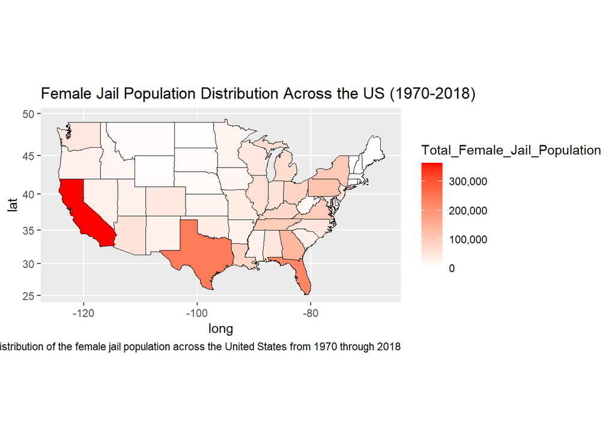

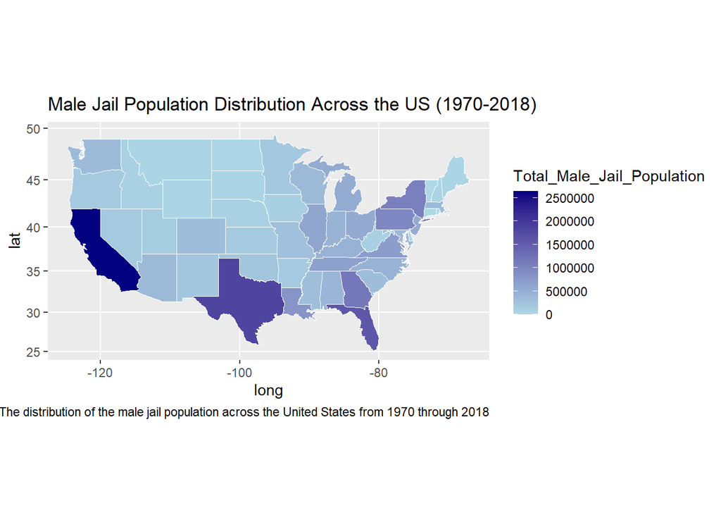

Summary:

The question I decided to answer using the two maps above is: what is the jail distribution by gender across the United States? First of all, from both the maps, we can see that the most jail population is in California state with Texas and Florida closely following behind.If one looks closely at the key of both maps, the numbers are significantly different. The maximum total male population in jail is over 2,500,000 whereas the maximum total female population in jail is below 400,000. From this, we can see how the male population is jailed more overall throughout the United States compared to the female population.